# Thinking causally

Estimands, DAGs, and model specification

Sebastian Ramirez-Ruiz

European University Institute (EUI)

October 16, 2026

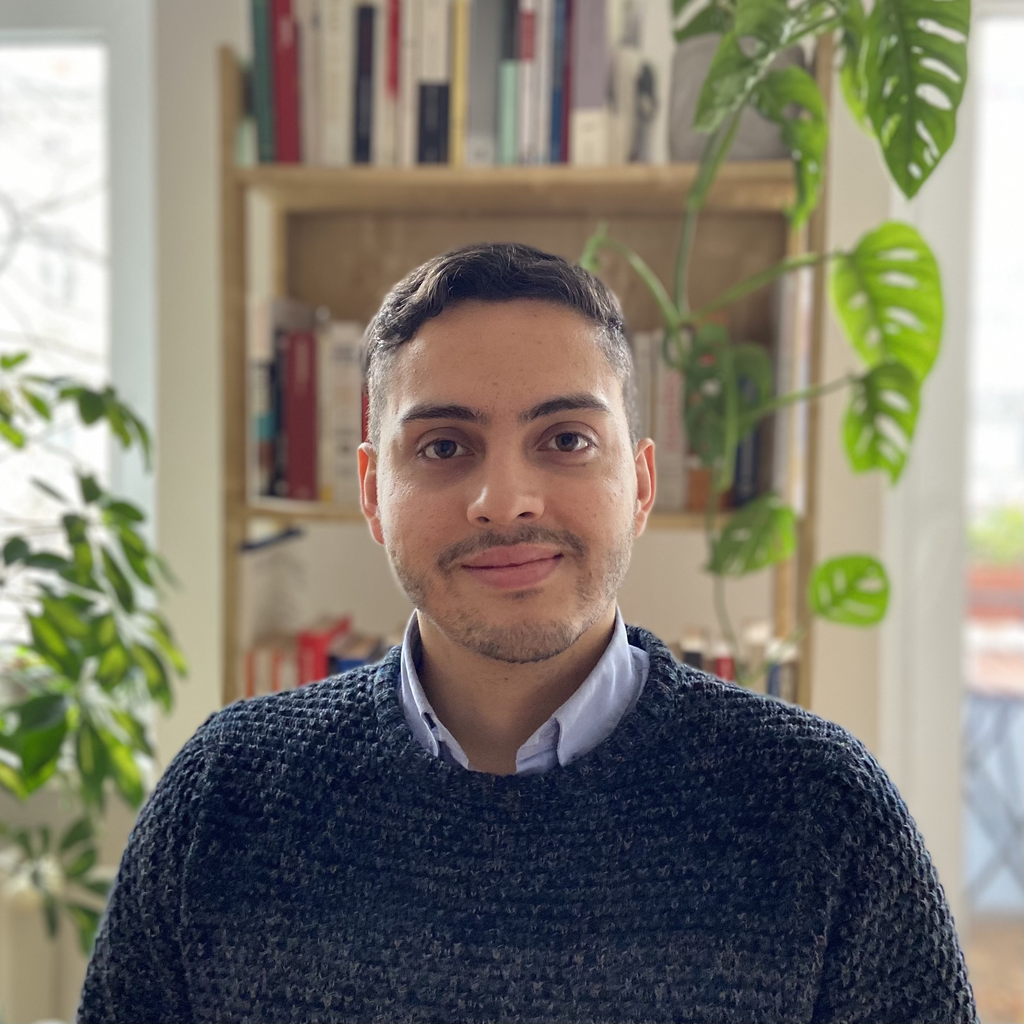

I am [Sebastian Ramirez-Ruiz](https://seramirezruiz.github.io/), or just Sebastian.

Part-time Assistant Professor in Quantitative Methods and Max Weber Fellow (Department of Political and Social Sciences)

sebastian.ramirezruiz@eui.eu

I am a **computational social scientist** researching how **political decisionmakers** engage with **evidence** and **information**, and how these interactions shape policy and governance across contexts.

## Two questions before any estimation

With Kevin, you asked **what a regression is for**: description, prediction, or causal inference.

**Week 3 (today)**

What exactly are we trying to estimate?

**Weeks 4–5**

Do our numbers measure the concepts we care about?

Both questions come before you choose a model.

## This session

Thinking causally

Causation and causal reasoning, counterfactuals, potential outcomes, and the biases of naive comparisons

What is your estimand?

Unit-specific quantity and target population, stated before any model

DAGs and good and bad controls

Confounders, mediators, colliders, the backdoor criterion, and why more controls is not safer

Where do your data come from?

Knox, Lowe & Mummolo (2020) in depth: selection, data-generating processes, and what records can and cannot tell us

Practice

Some group discussion today; DAGs and simulations in R in Lab 3 on Monday

# Why causation matters

## Why causation matters

Causation: a poor man’s working definition

- a.k.a. causality, cause and effect
- The idea that one variable [event, process, object; the cause] leads to another variable [event, process, object, outcome; the effect]

Causal reasoning

- The process of studying and identifying causality (*ruling out non-causal sources of association*)
- **Causal inference** is one way of doing causal reasoning

**Side note: what can be a cause?** The **manipulationist** camp holds there is no causation without manipulation (Holland 1986): only things we could, in principle, intervene on are causes, so “the effect of race” or “the effect of sex” is *not a thing* for them. The **difference-making** (or structural) camp counts anything that makes a difference to the outcome. Others break attributes into manipulable parts (Sen & Wasow 2016: race as a “bundle of sticks”). That is why we start with a loose, working definition and get precise once we define potential outcomes.

## Why causation matters for your thesis

**If you are here, my hunch is…**

- you are writing an empirical research paper or thesis
- you are interested in the effect of *X* on *Y*
- you use observational data, e.g., survey data or time-series cross-sectional data, and have lots of information about your cases
- you are asking: should I control for *Z*? Could it actually introduce problems?
- you are thinking you should control for *U*, but you cannot observe it. What to do?
- you opened social media and saw yet another new estimator. What to do?
- ultimately, **you think some X might affect Y and want to find out**

## Does going to the opera make you live longer?

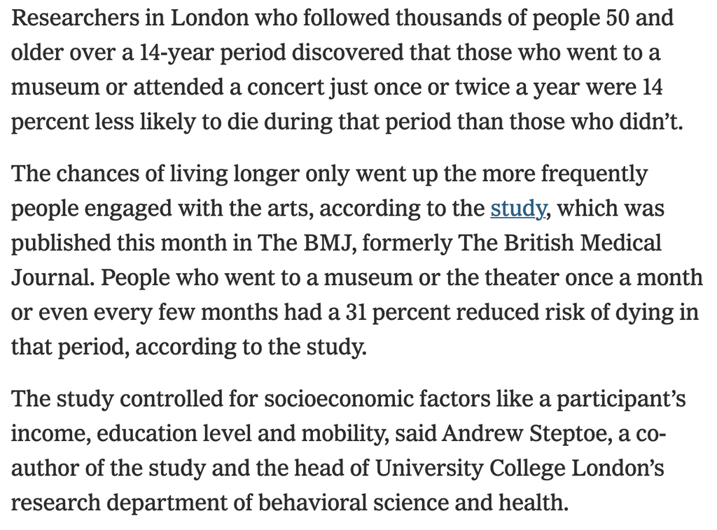

Source: [Cramer, NYTimes (2019)](https://www.nytimes.com/2019/12/22/us/arts-health-effects-ucl-study.html)

## Does going to the opera make you live longer?

[figure not shown]

Source: [Fancourt, Steptoe / BMJ (2019)](https://www.bmj.com/content/367/bmj.l6377)

## Does going to the opera make you live longer?

[figure not shown]

## Does going to the opera make you live longer?

**Different sources of association between X and Y**

1. X may have caused Y.
2. Y may have caused X.
3. X and Y may share one or more common causes.
4. The association may have been induced by conditioning on a common effect of X and Y.
5. Chance.

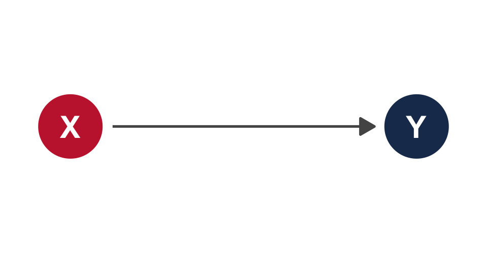

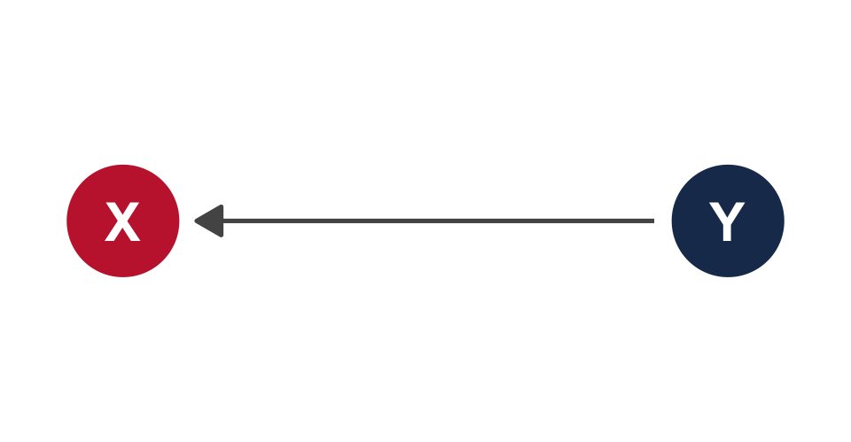

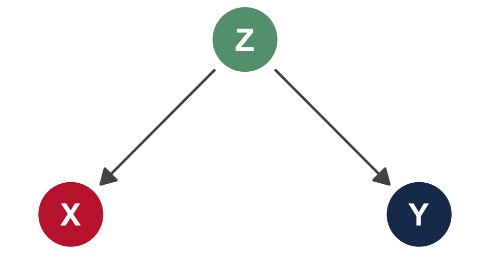

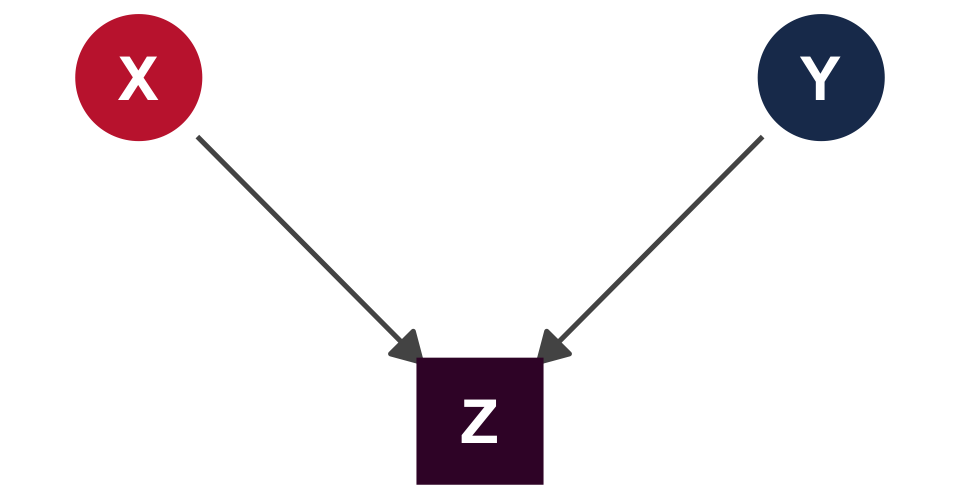

## Empirical regularities, causality, and the enterprise of writing papers… (?)

[figure not shown]

Source: [Tyler Vigen](https://tylervigen.com/spurious/correlation/2187_poor-air-quality-in-oklahoma-city_correlates-with_google-searches-for-funny-cat-videos) | [AI paper](https://tylervigen.com/spurious/research-papers/2187_felines-and-fumes-the-farcical-fascination-with-funny-cat-videos-in-face-of-air-pollution-in-oklahoma-city.pdf)

## Empirical regularities, causality, and the enterprise of writing papers… (?)

[figure not shown]

Source: [Tyler Vigen](https://tylervigen.com/spurious/correlation/1783_associates-degrees-awarded-in-mathematics-and-statistics_correlates-with_google-searches-for-dollar-store-near-me) | [AI paper](https://tylervigen.com/spurious/research-papers/1783_counting-the-costs-connecting-associates-degrees-in-math-and-statistics-with-dollar-store-searches.pdf)

## Why causality is important

[figure not shown]

## From associations to causes

**So, how do we figure out correlation?**

Math and statistics.

**And how do we figure out causation?**

Philosophy. Imagination. Theory. Counterfactual thinking. No (*some*) math.

## From associations to causes

**Causal inference** is the process of…

- … ruling out non-causal sources of association,
- … highlighting the assumptions necessary to do so, and
- … providing empirical evidence to support or refute these assumptions.
- Today we will mainly think about **causal**, not statistical inference.
- Our understanding of causality is probabilistic rather than deterministic: X is a cause of Y if X is a cause of Y for some subjects in a population (or if changes in X lead to changes in the probability distribution in Y)
- Most of the time, we are interested in the existence and magnitude of a causal effect. Interest in the mechanism will come later (for now)

# Counterfactual causality

## Thinking in terms of counterfactuals

### The Neyman-Rubin causal model

- It is a formal approach to do causal inference that fueled the **potential outcomes framework (POF)**
- Up until today, it’s the mainstream framework to (statistically) talk about causation

### The idea of potential outcomes

- The POF assumes that each subject has a potential outcome under each treatment state
- Evidently, each subject can only be observed in one treatment state at any point in time
- The idea is to think about the counterfactual outcome that would have been observed had the treatment been different

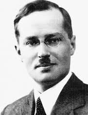

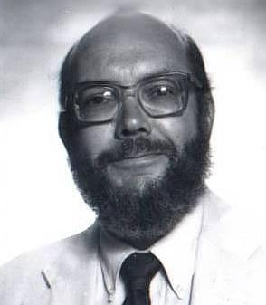

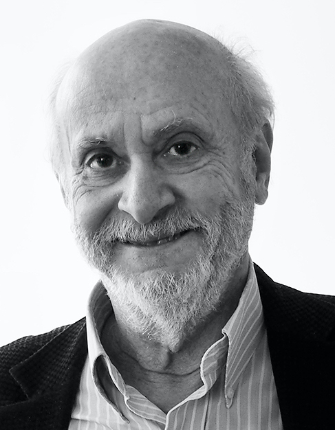

## Running example: roommates and the contact hypothesis

- **Context:** Prejudice between ethnic groups is persistent and politically consequential. Allport’s **contact hypothesis** holds that, under the right conditions, interpersonal contact with members of an out-group reduces prejudice.
- **Intervention:** First-year students share dorm rooms. Some live with a roommate from a different ethnic group (an out-group roommate), others with someone from their own group.

**Research question:** Does living with an out-group roommate reduce a student’s prejudice?

## Defining causal effects: individual treatment effects

- Assume that each subject $i$ in a population of interest can be exposed to two alternative states of a cause: treatment, $D_i = 1$ (out-group roommate), and control, $D_i = 0$ (in-group roommate)
- The POF assumes that each subject has a potential outcome under both treatment states, $Y_i(1)$ and $Y_i(0)$
- An individual treatment effect (ITE) can thus be defined as $\tau_i = Y_i(1) - Y_i(0)$
- Evidently, each subject can only be observed in one treatment state *at any point in time*
- Therefore, the ITE is a non-observable counterfactual (what Holland, 1986, labels the **fundamental problem of causal inference**)
- Note that even successive exposure of the same subjects to alternative causal states does not allow for the observation of the ITE — Why?

## Defining causal effects: notation

- Binary causal variable, $D_i = 1$ for students with an out-group roommate, $D_i = 0$ for students with an in-group roommate
- Observable outcome variable:

$Y_i = Y_i(1) \text{ if } D_i = 1$  
$Y_i = Y_i(0) \text{ if } D_i = 0$  
$Y_i = D_i\,Y_i(1) + (1-D_i)\,Y_i(0)$

| Group | Under treatment $(D=1)$ | Under control $(D=0)$ |
| --- | --- | --- |
| Treated $(D=1)$ | Observable as $Y_i(1)$ | Counterfactual $Y_i(0)$ |
| Untreated $(D=0)$ | Counterfactual $Y_i(1)$ | Observable as $Y_i(0)$ |

## Defining causal effects: notation

- Binary causal variable, $D_i = 1$ for students with an out-group roommate, $D_i = 0$ for students with an in-group roommate
- Observable outcome variable:

$Y_i = Y_i(1) \text{ if } D_i = 1$  
$Y_i = Y_i(0) \text{ if } D_i = 0$  
$Y_i = D_i\,Y_i(1) + (1-D_i)\,Y_i(0)$

Why is the causal effect of $D$ on $Y$ not simply the difference between the upper-left and lower-right cell in the table?

| Group | Prejudice with an out-group roommate $(D=1)$ | Prejudice with an in-group roommate $(D=0)$ |
| --- | --- | --- |
| Has an out-group roommate $(D=1)$ | Observable as $Y_i(1)$ | Counterfactual $Y_i(0)$ |
| Has an in-group roommate $(D=0)$ | Counterfactual $Y_i(1)$ | Observable as $Y_i(0)$ |

## Defining causal effects: average treatment effects

- In the counterfactual modeling tradition, attention is usually on estimating various average treatment effects, $\text{ATE} = E[Y_i(1)] - E[Y_i(0)]$, for groups of subjects
- ATE so defined is not observable either — Why?
- What we can immediately calculate from observed $Y$ and $D$ is the naïve estimator of the ATE:

$\text{NATE} = E[Y_i(1) \mid D_i = 1] - E[Y_i(0) \mid D_i = 0]$

- NATE will correspond to ATE only under very specific conditions regarding the process by which subjects are assigned to causal states. Think of:
  - A subject decides itself whether to enter one causal state or another (students choose their roommates)
  - An outside actor chooses to allocate subjects to one state or another (the housing office)
  - A random allocation by some EUI researcher decides
  - Some combination thereof

## Eight students: the world with full information

Eight first-year students. We imagine we can see both potential outcomes (prejudice, 0–10).

Students **chose** their roommates.

Average of the last column:

$$\text{ATE} = \frac{-4}{8} = \textcolor{#c6273b}{-0.5}$$

| Student | $Y_i(0)$ | $Y_i(1)$ | $\tau_i$ | $D_i$ |
| --- | --- | --- | --- | --- |
| 1 | 6 | 5 | −1 | 0 |
| 2 | 4 | 2 | −2 | 1 |
| 3 | 4 | 4 | 0 | 0 |
| 4 | 6 | 7 | 1 | 0 |
| 5 | 3 | 1 | −2 | 1 |
| 6 | 2 | 2 | 0 | 1 |
| 7 | 8 | 7 | −1 | 0 |
| 8 | 4 | 5 | 1 | 0 |

## …and what we actually observe

Compare the two groups as we find them:

$$\frac{2+1+2}{3} - \frac{6+4+6+8+4}{5} = 1.67 - 5.6$$

$$\text{NATE} = \textcolor{#c6273b}{-3.93}$$

The naive comparison says contact cuts prejudice by almost 4 points. The true average effect is half a point.

| Student | $Y_i(0)$ | $Y_i(1)$ | $\tau_i$ | $D_i$ |
| --- | --- | --- | --- | --- |
| 1 | 6 |  |  | 0 |
| 2 |  | 2 |  | 1 |
| 3 | 4 |  |  | 0 |
| 4 | 6 |  |  | 0 |
| 5 |  | 1 |  | 1 |
| 6 |  | 2 |  | 1 |
| 7 | 8 |  |  | 0 |
| 8 | 4 |  |  | 0 |

## ATE, ATT, ATC: three target populations

- Same unit-level effects, averaged over different people:

$$\begin{aligned}
\text{ATE} &= E[Y_i(1) - Y_i(0)] \\
\text{ATT} &= E[Y_i(1) - Y_i(0) \mid D_i = 1] \\
\text{ATC} &= E[Y_i(1) - Y_i(0) \mid D_i = 0]
\end{aligned}$$

- **Your turn (1 min)**: compute the ATT and the ATC from the table.
- ATT $= \frac{-2-2+0}{3} = -1.33$ · ATC $= \frac{-1+0+1-1+1}{5} = 0$
- Contact “works” for those who sought it out, and not for the rest. Which one is your estimand?

| Student | $Y_i(0)$ | $Y_i(1)$ | $\tau_i$ | $D_i$ |
| --- | --- | --- | --- | --- |
| 1 | 6 | 5 | −1 | 0 |
| 2 | 4 | 2 | −2 | 1 |
| 3 | 4 | 4 | 0 | 0 |
| 4 | 6 | 7 | 1 | 0 |
| 5 | 3 | 1 | −2 | 1 |
| 6 | 2 | 2 | 0 | 1 |
| 7 | 8 | 7 | −1 | 0 |
| 8 | 4 | 5 | 1 | 0 |

## Defining biases

- We can define the ATE as a weighted average of ATT and ATC:

$$\begin{aligned}
\text{ATE} &= \pi \cdot \text{ATT} + (1-\pi) \cdot \text{ATC} \\
&= \pi\big(E[Y_i(1) \mid D_i=1] - E[Y_i(0) \mid D_i=1]\big) + (1-\pi)\big(E[Y_i(1) \mid D_i=0] - E[Y_i(0) \mid D_i=0]\big)
\end{aligned}$$

where $\pi$ is the proportion of subjects under treatment

- In our example, $\text{ATT} = -1.33$, $\text{ATC} = 0$ and $\pi = 3/8$, so:

$$\text{ATE} = \tfrac{3}{8} \cdot (-1.33) + \tfrac{5}{8} \cdot 0 = -0.5$$

- Recall that $\text{NATE} = E[Y_i(1) \mid D_i=1] - E[Y_i(0) \mid D_i=0] = 1.67 - 5.6 = -3.93$
- Total bias of NATE as an estimate of ATE is simply $\text{NATE} - \text{ATE} = -3.93 - (-0.5) = -3.43$
- Using the above expressions, we can further decompose total bias into its component parts

## Defining biases

$$\begin{aligned}
\text{Total bias} &= \textcolor{#c6273b}{\text{NATE}} - \textcolor{#1d375b}{\text{ATE}} \\[6pt]
&= \textcolor{#c6273b}{E[Y_i(1) \mid D_i=1] - E[Y_i(0) \mid D_i=0]} - \textcolor{#1d375b}{\big\{\pi \cdot \text{ATT} + (1-\pi) \cdot \text{ATC}\big\}}
&& \textcolor{#888888}{\text{definitions}} \\[6pt]
&= \textcolor{#c6273b}{\big(E[Y_i(1) \mid D_i=1] - E[Y_i(0) \mid D_i=1]\big) + \big(E[Y_i(0) \mid D_i=1] - E[Y_i(0) \mid D_i=0]\big)} - \textcolor{#1d375b}{\big\{\cdots\big\}}
&& \textcolor{#888888}{\pm\, E[Y_i(0) \mid D_i=1]} \\[6pt]
&= \textcolor{#c6273b}{\text{ATT} + \big(E[Y_i(0) \mid D_i=1] - E[Y_i(0) \mid D_i=0]\big)} - \textcolor{#1d375b}{\big\{\text{ATT} - (1-\pi)(\text{ATT} - \text{ATC})\big\}}
&& \textcolor{#888888}{\pi = 1 - (1-\pi)} \\[6pt]
&= \underbrace{\textcolor{#639E7D}{E[Y_i(0) \mid D_i=1] - E[Y_i(0) \mid D_i=0]}}_{\textcolor{#639E7D}{\text{baseline bias} \;=\; 3 - 5.6 \;=\; -2.6}}
\;+\; \underbrace{\textcolor{#AD9356}{(1-\pi)\big(\text{ATT} - \text{ATC}\big)}}_{\textcolor{#AD9356}{\text{differential treatment effect bias} \;=\; \frac{5}{8}(-1.33) \;=\; -0.83}}
&& \textcolor{#888888}{\text{ATTs cancel}}
\end{aligned}$$

- where baseline bias is the difference in the average outcome *in the absence of treatment* between those under treatment and those under control: students who chose out-group roommates were **less prejudiced to begin with**
- and differential treatment effect bias is the difference in the average treatment effect between treated and control groups, weighted by the share in the control state: contact **helps more** those who sought it
- $\therefore$ Total bias $=$ baseline bias $+$ differential treatment effect bias $= -2.6 - 0.83 = -3.43$

What happens when “total bias” is equal to zero?

$\text{NATE} = \text{ATE}$

What we can estimate with “realized” outcomes = True effect

## SUTVA: when is $Y_i(d)$ even well-defined?

The stable unit treatment value assumption has two parts:

- **No interference**: student $i$’s prejudice does not depend on who *other* students room with.
- **One version of the treatment**: “out-group roommate” means the same thing for everyone.

In dorms, both are doubtful: friends of friends, shared corridors, and roommates who barely talk vs. become close friends.

If SUTVA fails, the estimand itself is not defined, before any data problem.

## Ignorability: what randomization buys

- If $\big(Y_i(1), Y_i(0)\big) \perp\!\!\!\perp D_i$, both biases are zero and $\text{NATE} = \text{ATE}$.
- Randomization guarantees this by design: a coin, not the student, decides $D_i$.
- Without randomization we hope for conditional ignorability:

$$\big(Y_i(1), Y_i(0)\big) \perp\!\!\!\perp D_i \mid \textcolor{#639E7D}{X_i}$$

within groups of students with the same $X$, roommate type is as good as random

But **which** $X$? That is what DAGs answer.

# What is your estimand?

## A coefficient is an answer. What was the question?

Running example: does living with an out-group roommate reduce prejudice? (Allport’s contact hypothesis)

```r
lm(prejudice ~ outgroup_roommate + openness + outgroup_friends, data = dorms)
```

Description

How much less prejudiced are students with out-group roommates than similar students without?

Prediction

Does knowing a student's roommate help us forecast their prejudice score?

Causal effect

How much would a student's prejudice change if we assigned them an out-group roommate?

Same (*code*) test, three questions. The (*code*) test does not tell you which one you answered.

$\hat\beta$ is not an estimand.  
It is an estimate **of something**.

Say what.

## Set, link, learn: from theory to evidence

Evidence points  
to new questions

Theory or  
general goal

⟶

Theoretical  
estimands

⟶

Empirical  
estimands

⟶

Estimation  
strategies

↑

Set

a specific  
target

by argument

Unit-specific quantity,  
target population

today: estimands

↑

Link

to observable  
data

by assumption

Potential outcomes,  
DAGs

today: PO and DAGs

↑

Learn

how to estimate  
from data

by data

OLS regression,  
machine learning

Weeks 1-3 and 6-8

Most papers start with the estimation strategy. Lundberg, Johnson & Stewart ask us to start by **setting** the target.

Lundberg, Johnson & Stewart (2021), “What is your estimand?”, *American Sociological Review* 86(3)

## A theoretical estimand has two parts

**1. Unit-specific quantity**

What we would want to know about each unit $i$, e.g. how student $i$’s prejudice would differ with an out-group roommate.

**2. Target population** $\mathcal{P}$

Over whom we aggregate, e.g. all first-year students in university dorms across the EU (?).

$$\tau \;=\; \frac{1}{|\mathcal{P}|}\sum_{i \in \mathcal{P}} \Big[\textcolor{#1d375b}{Y_i}(\textcolor{#c6273b}{1}) - \textcolor{#1d375b}{Y_i}(\textcolor{#c6273b}{0})\Big]$$

where $Y_i(1)$ and $Y_i(0)$ are student $i$’s prejudice with and without an out-group roommate

Notice what is missing: no regression, no $\beta$, no control variables.

## Descriptive estimands are estimands too

Not every good question is causal. A **descriptive** estimand:

$$\tau_{\text{gap}} \;=\; E\big[\textcolor{#1d375b}{Y_i} \mid \text{out-group roommate}\big] - E\big[\textcolor{#1d375b}{Y_i} \mid \text{in-group roommate}\big], \quad i \in \mathcal{P}$$

the prejudice gap between the two groups of students, as they are

- No counterfactual, no DAG, no “controls” needed.
- Perfectly legitimate, if you **say so** and do not slip into causal language.
- The trouble starts when a descriptive estimate is read as a causal one.

## The target population is part of the question

Roommates

Boisjoly et al. (2006) use roommates who were **randomly assigned**, but only among students whose stated housing preferences allowed it.

→ The estimand is the effect **for those students**, not for everyone.

Anonymous CVs

Behaghel, Crépon & Le Barbanchon (2015) randomize anonymous CVs among firms that **volunteered** for the French program.

→ The estimand is the effect **among volunteers**, not the effect of a mandate for all firms.

A perfectly identified effect can still answer the wrong population’s question. We come back to this as **transportability** in Week 4.

Boisjoly, Duncan, Kremer, Levy & Eccles (2006), *AER* 96(5) · Behaghel, Crépon & Le Barbanchon (2015), *AEJ: Applied* 7(3)

## From theoretical to empirical estimand

The empirical estimand is written only in terms of things we can observe:

$$\sum_{x} \Big( E[\textcolor{#1d375b}{Y} \mid \textcolor{#c6273b}{D}{=}1, \textcolor{#639E7D}{X}{=}x] - E[\textcolor{#1d375b}{Y} \mid \textcolor{#c6273b}{D}{=}0, \textcolor{#639E7D}{X}{=}x] \Big)\, P(\textcolor{#639E7D}{X}{=}x)$$

where $D$ is the treatment, $Y$ the outcome, and $X$ a set of observed covariates

- It equals the theoretical estimand **only under assumptions**: here, that $X$ captures every reason why treated and untreated students differ.
- Making that link is the **Link** step: its identification assumptions are what a DAG makes explicit (after the break).
- The **Learn** step, estimation (OLS, matching, weighting…), comes **last**.

Your turn ✏️ (~3 min, with the person next to you)

Pick **one** question and write down its **unit-specific quantity** and **target population**.  
Is it descriptive or causal?

1. Does living with an out-group roommate reduce prejudice?
2. Do anonymous CVs reduce hiring discrimination?
3. Do protected bike lanes increase cycling?

Would a regression of Y on the treatment plus controls give you that quantity? Why (not)?

Break

10 minutes

# DAGs: drawing your assumptions

## What a DAG says, and what it doesn’t

- **Nodes** are variables, observed or unobserved.
- An **arrow** says “may cause”. It makes no claim about size or sign (*i.e., non-parametric*).
- A **missing arrow** is a strong claim: no direct effect at all.
- **Acyclic**: no variable causes itself through a loop. Time moves forward.
- Drawn from **theory and knowledge**, not from the data.

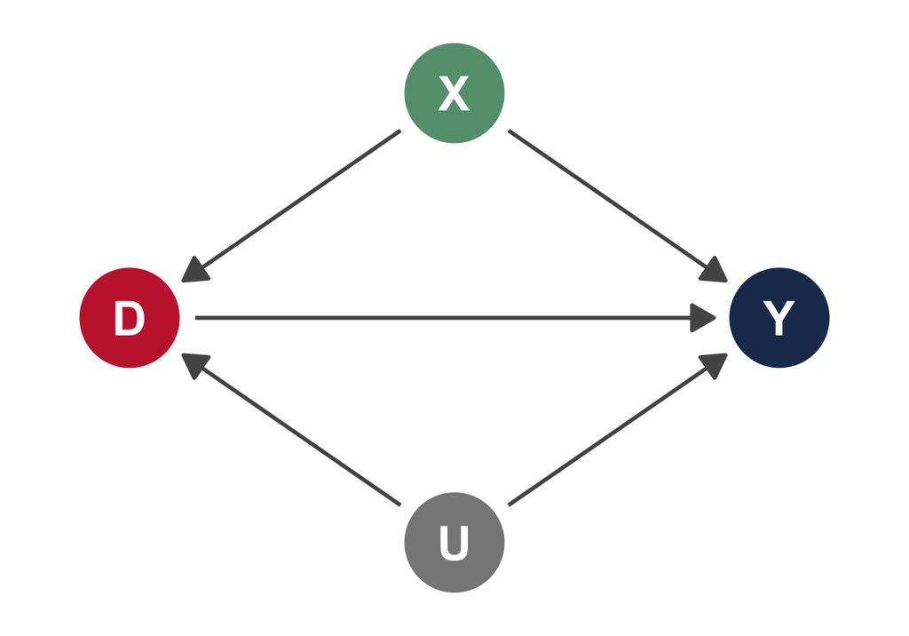

Two languages for the same problem, with different strengths: DAGs make complex assumptions **visible**; potential outcomes tie them to **assignment, heterogeneity, and estimation** (Imbens 2020).

## Three building blocks: confounders, mediators, colliders

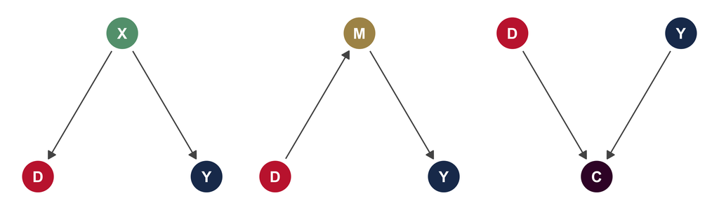

X is a **confounder**

D ← X → Y

M is a **mediator**

D → M → Y

C is a **collider**

D → C ← Y

In the DAG literature, these three structures are also called a *fork*, a *chain*, and an *inverted fork* (or collider).

## Two rules for paths

A **path** is any sequence of arrows between two nodes, whatever their direction. An open path transmits association.

**Rule 1**

Paths through a confounder or a mediator are **open**.  
Conditioning on the confounder or mediator closes the path.

**Rule 2**

Colliders are **closed**.  
Conditioning on a collider, or on anything it causes, opens the path.

The association is causal when the path follows the arrows from $D$ to $Y$: directly ($D \rightarrow Y$) or through a mediator ($D \rightarrow M \rightarrow Y$).

It is non-causal when the path runs back through a confounder ($D \leftarrow X \rightarrow Y$) or through a collider we conditioned on ($D \rightarrow C \leftarrow Y$).

“Conditioning” = controlling in a regression, stratifying, matching, **or selecting the sample**.

## Conditioning on a collider: the bike-counter problem

“Conditioning” = controlling in a regression, stratifying, matching, **or selecting the sample**.

Fair warning: I am very much into cycling (and a bit unidimensional), so expect bike stuff to keep popping up in this course.

- Do protected bike lanes increase cycling? We only have data from districts with automatic **bike counters**.
- We have reason to believe that cities install counters where lanes exist **or** where cycling is already high: the counter is a collider.
- In the sample, a district **without** lanes usually got its counter because cycling was already high.
- So no-lane districts look like heavy-cycling places: lanes and cycling become negatively associated among counter districts.
- The lane estimate is biased **downward**. It can shrink, vanish, or flip sign, even if lanes truly raise cycling.
- More counter districts do not help: the bias comes from **who is in the data**, not from sample size.

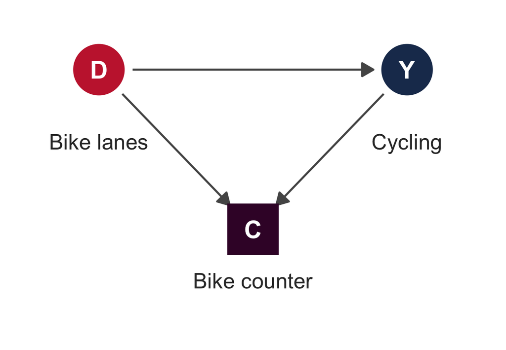

## The backdoor criterion

A set of variables $Z$ identifies the effect of $D$ on $Y$ if

1. no variable in $Z$ is a **descendant** of $D$, and
2. $Z$ **blocks every backdoor path**: every path between $D$ and $Y$ that starts with an arrow **into** $D$.

**Recipe**

1. Draw the DAG for your estimand.
2. List all paths from $D$ to $Y$.
3. Mark the backdoor paths, and whether each is open or closed.
4. Find a set that closes the open ones **without** opening new ones (Rule 2!).

Let’s do this together 🔍

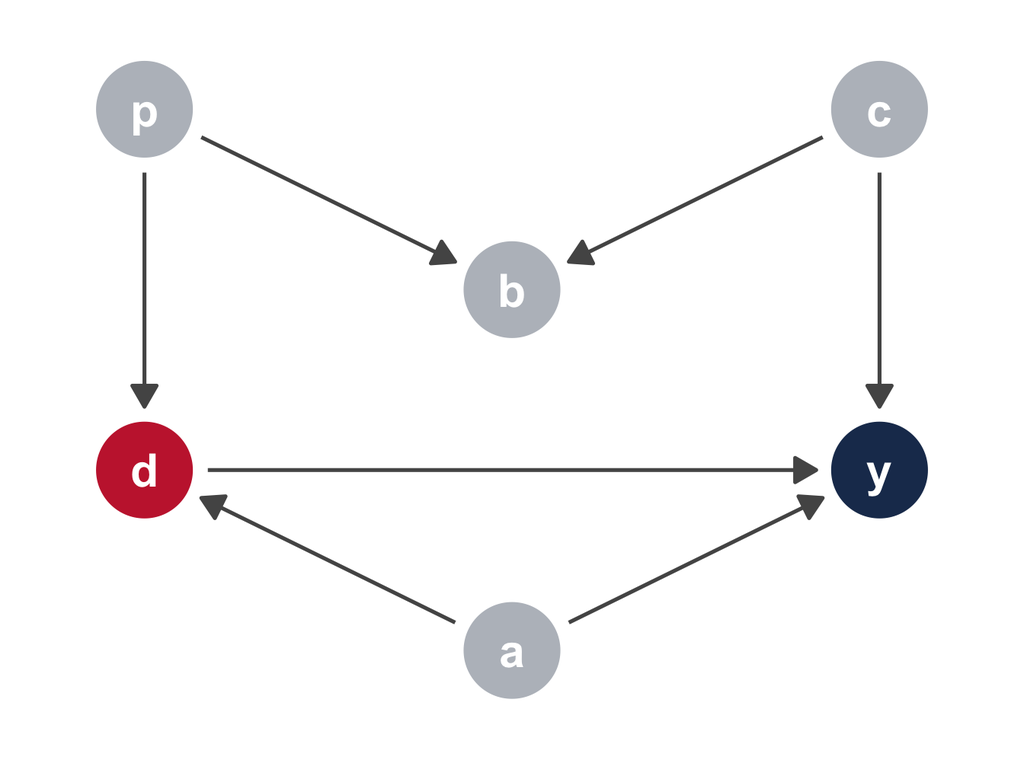

1. Identify the causal and non-causal paths from d to y.
2. Are the non-causal paths **naturally closed** (by a collider)?
3. What should we **condition on** to close the open non-causal paths?

A colleague controls for b “to be safe”. What else must they add?

# Good and bad controls

## More controls is not safer

Good: removes bias

Confounders, and proxies of unobserved confounders, that sit on open backdoor paths

Neutral, but helps precision

Causes of the outcome only (e.g., baseline prejudice): smaller standard errors, no bias

Neutral, but hurts precision

Causes of the treatment only (e.g., dorm-allocation lottery number): larger standard errors, and they amplify any remaining bias

Bad: creates bias

Mediators, colliders and their descendants, descendants of the treatment, and "M-bias" pre-treatment colliders

Cinelli, Forney & Pearl (2024), “A crash course in good and bad controls”, *Sociological Methods & Research* 53(3)

## Bad control 1: controlling away the effect

- Contact may reduce prejudice **through** friendships with out-group members.
- Controlling for out-group friendships at follow-up blocks that path.
- The coefficient on roommate type then shows only what is left: not the total effect.
- Same problem with any **post-treatment** variable, including in experiments: controlling for it, dropping people on it, or subsetting on it (Montgomery, Nyhan & Torres 2018).

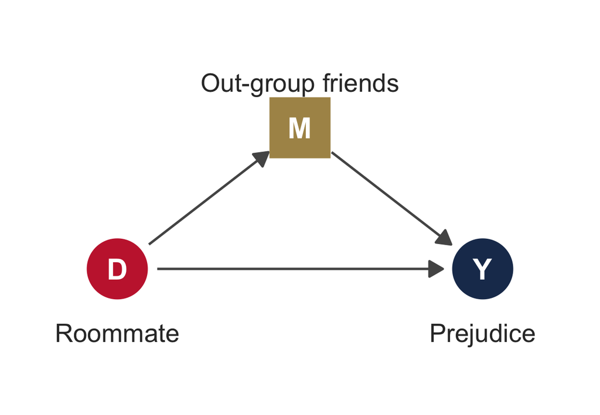

## Bad control 2: colliders manufacture correlation

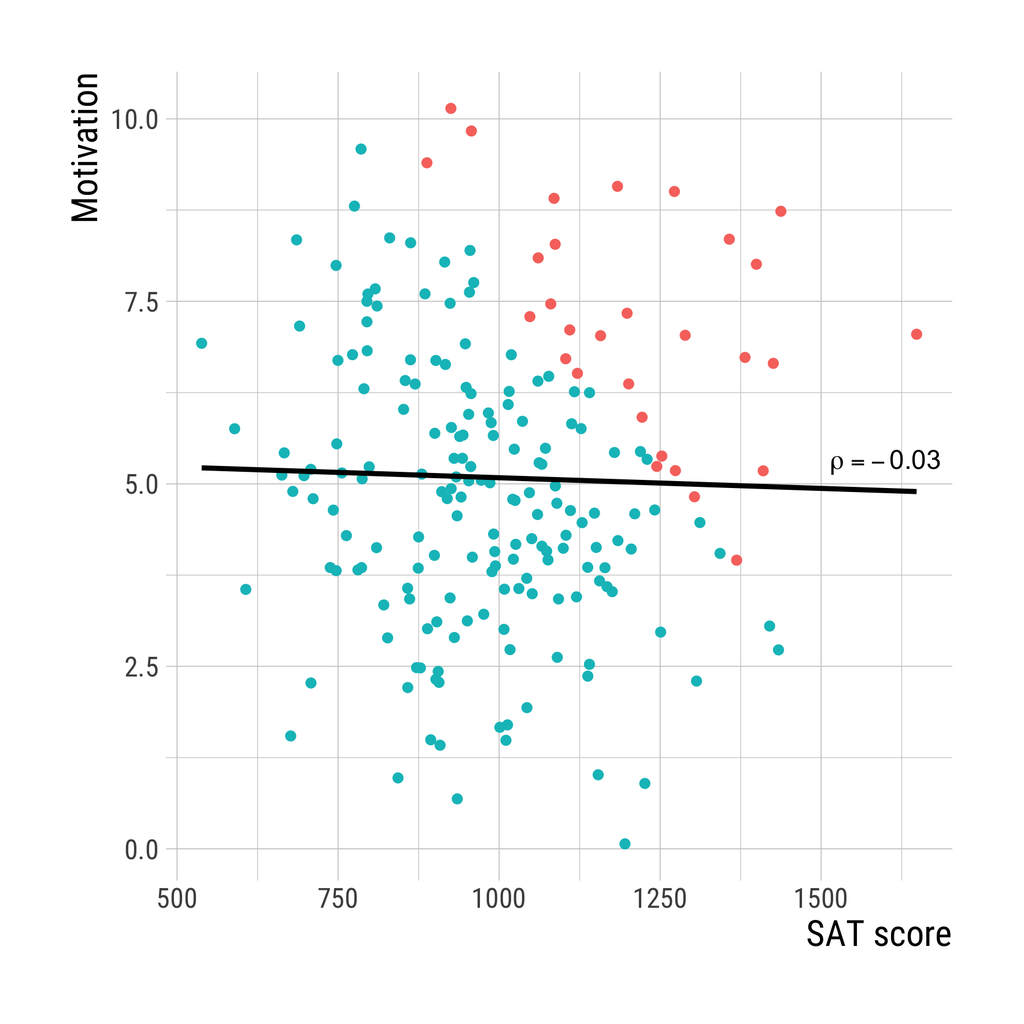

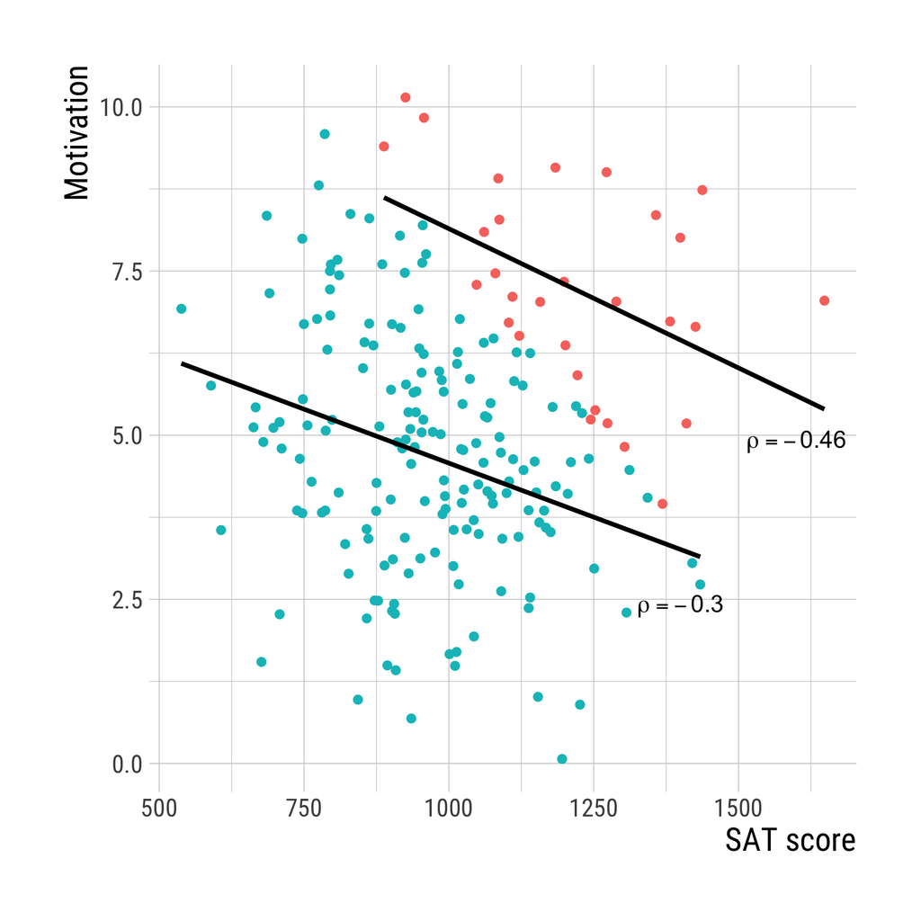

SAT score and motivation are independent, but both get you admitted. **Among admitted students**, they look negatively related.

In the lab on Monday, you will simulate both mistakes:

**Skip a confounder:** shoe size “predicts” salary, until you control for sex.

**Control for a collider:** beauty and talent look negatively related, once you condition on celebrity.

These examples are silly on purpose.

The things we study are not. Contact and prejudice, bike lanes and cycling, race and police force.

Ask yourself how obvious the right model would be there.

## Opera, revisited: what did the authors control for?

> “We adjusted models for **demographic variables** (age, sex, marital status, ethnicity, educational qualifications, wealth, employment status, and occupational status); **health related variables** (eyesight, hearing, depressive symptoms, other psychiatric conditions, diagnosis of cancer, lung disease or cardiovascular disease, history of any other long-term condition, smoking, alcohol consumption, sedentary behaviours, mobility, problems in undertaking activities of daily living, osteoporosis, and cognition); and **social covariates** (loneliness, number of close friends, living alone, frequency of civic engagement, frequency of social engagement, and whether participants had a hobby or pastime).”

## Opera, revisited: suppose this is the DAG

Not *the* true DAG, but *a* DAG: our theory of how arts attendance, health, wealth, and social life fit together, written down.

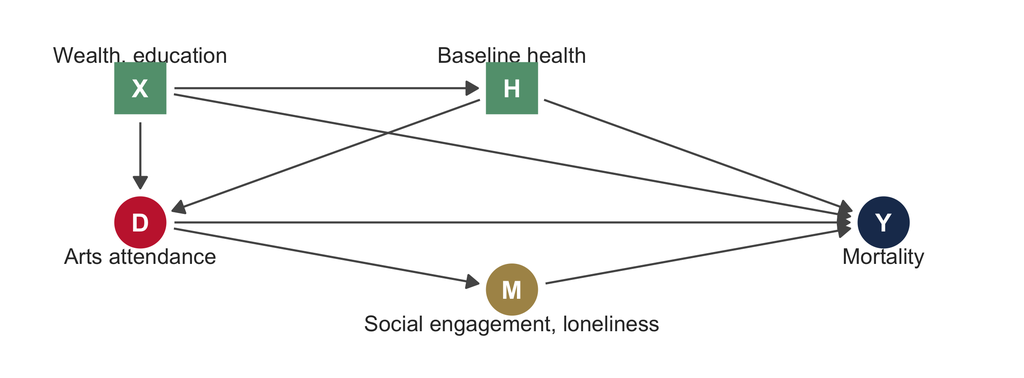

**If** this is the world: adjust for wealth, education and **baseline** health; leave social engagement out.

The leverage of a DAG: every arrow, and every **missing** arrow, is a claim others can see and contest.

## Contest it: a critic’s DAG

- A critic: people with more **energy** and fewer **undiagnosed illnesses** both go out to the opera **and** live longer.
- Baseline health only partly measures this. The rest is an unobserved common cause, $U$.
- That adds a backdoor path, Arts ← $U$ → Mortality, that no measured control closes.
- The disagreement is now **precise**: one arrow, which better health data or a different design could settle.

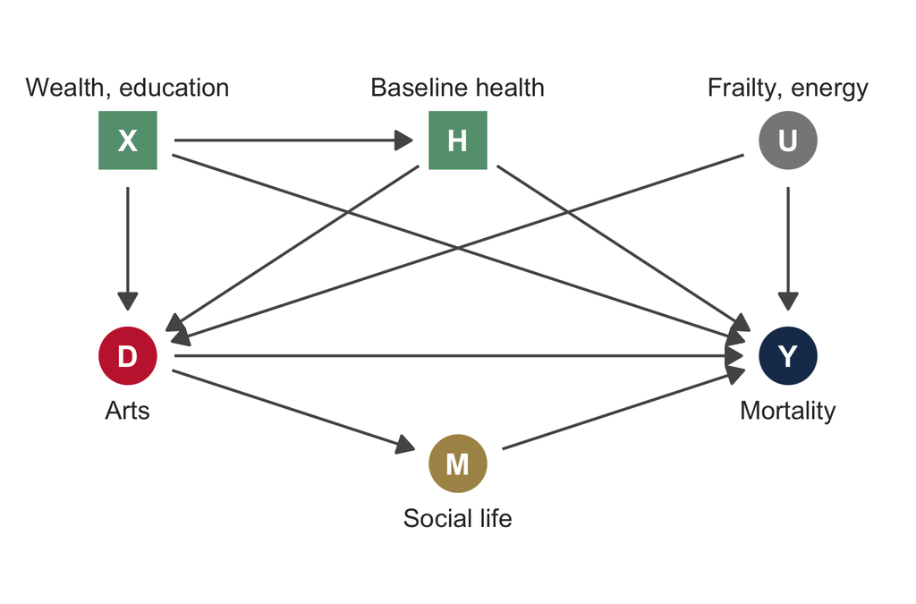

Disagreeing about a DAG is a scientific debate, not a matter of taste: you have to say which arrow, and why.

# Where do your data come from?

## Is there racial bias in police use of force?

- A question with enormous stakes, and one where the data are produced by the very behavior under study. The usual source: **administrative records** of police–civilian encounters.
- Previous research: Fryer (2019) analyzes police records with rich controls for context and civilian behavior.

Non-lethal force · NYC stop-and-frisk records

>50% more likely

for Black and Hispanic civilians; controls reduce the gap but do not eliminate it

Officer-involved shootings

no racial difference

in the raw data or with controls for context

The second finding became the headline: no bias in lethal force… but both comparisons are made **only among people already in a ‘recorded’ encounter**. If race shapes who ends up in those encounters, “no difference” may be exactly what discrimination looks like in the records.

- So before judging either number, ask two questions: what is the estimand, and who is in the data?

Fryer (2019), “An empirical analysis of racial differences in police use of force”, *Journal of Political Economy* 127(3): 1210–1261

## How does a row get into the data?

1. Encounter

An officer observes a civilian

not recorded

→

2. Stop or not?

The officer decides whom to stop

race may matter here

→

3. Force or not?

The officer decides how to act

and here

→

4. The record

One row per stop: the researcher's dataset

If race affects step 2, the people in the records are already a selected group, before anyone runs a regression.

## Draw the data-generating process as a DAG

- Race ($D$) may affect whether someone is stopped ($S$), and whether force is used ($Y$)
- Suspicion or circumstances ($U$), unobserved, affect both stopping and force
- Records contain **only** $S = 1$: every analysis of records conditions on $S$
- $S$ is a collider on $D \to S \leftarrow U \to Y$: conditioning on it opens a path that has nothing to do with how force is used
- And the stop is also a **mediator** ($D \to S \to Y$): even the question “what is the effect?” needs care

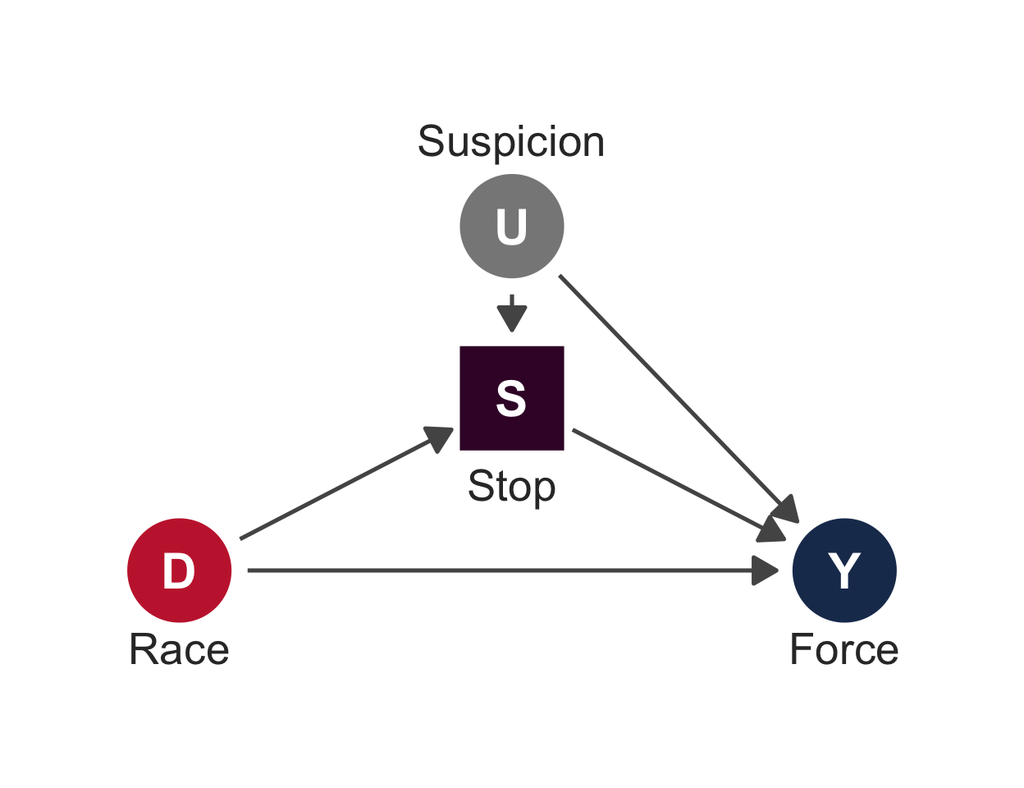

Knox, Lowe & Mummolo (2020), *APSR* 114(3)

## How selection can hide discrimination

I simulated a city where officers stop minority civilians at **lower** levels of suspicion (i.e., lower trheshold for a stop), and once stopped, are more likely to use force on a minority civilian than on a white civilian with the same suspicion.

- In the records, minority civilians face force **4.5 pp less** often
- Yet the true effect is **+9.9 pp** for the same people
- Stopped minority civilians were stopped on **weaker suspicion**, so they look “less dangerous” in the records: the comparison masks the discrimination entirely, and a “no difference” finding is no evidence of no bias

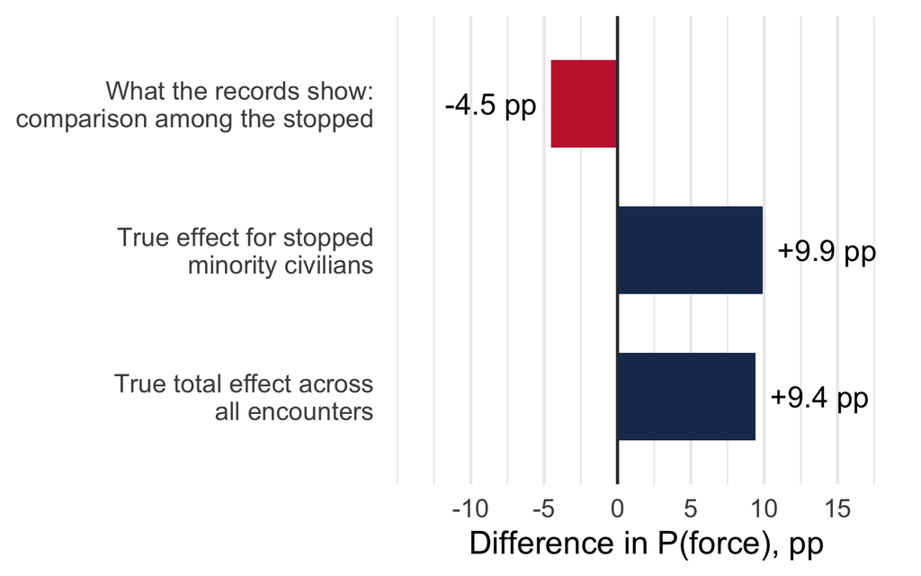

## Which estimand? Three candidates

Total effect, all encounters

How much does a civilian's race change the chance that an encounter ends in force?

Needs data on encounters that were never recorded

Difference among the stopped

Among people who were stopped, how does force differ by race?

What records estimate: a description of a selected group, not the effect of race

Effect among those stopped regardless of race

For civilians police would stop whatever their race, does race change the use of force?

Not identified from records without strong assumptions

The data *can probably* answer the middle question; the public (*and policy*) debate ask the first or the third. Name the estimand first.

## What Knox, Lowe & Mummolo do

- Formalize the problem with potential outcomes and mediation: the stop is both a mediator and a selection rule
- Derive the exact bias of the standard approach, and show that in most cases no set of controls can remove it
- Offer a bias correction and **nonparametric sharp bounds** for race effects, under explicit assumptions
- Re-analyzing Fryer’s (2019) NYPD data: traditional estimates can **severely understate** racially biased policing, or mask it entirely
- Propose a better design: record **encounters**, not only stops

Bronner (2020) gives the plain-language version: statistics on police interactions describe only the small, non-random subset of people police chose to engage, so the relationships in those data can shift. A collider, in disguise.

Knox, Lowe & Mummolo (2020), *APSR* 114(3): 619–637 · Bronner (2020), FiveThirtyEight

## Thinking with DAGs about how data are generated

Before analyzing any dataset, draw how a row comes to exist:

- Who could have entered the data? The population before any selection: all encounters, all applicants, all crashes
- Who decided whether they entered? Officers, judges, editors, reviewers, survey non-response, platforms
- Could that decision depend on your treatment or your outcome? If on both, you are conditioning on a collider
- What estimand do the data you have actually support? Often a narrower one than your question

Previous research is part of the data-generating process too. This is a bit of a pet peeve for Kevin and me: published findings are selected on statistical significance (Think of Week 1). The literature you read is a selected sample…

If time allows

Your turn 💬 (~5 min, groups of 3, then share)

Pick **one** ‘dataset’ (your own, or one below) and draw how a row comes to exist.

1. Asylum decisions in court records
2. Police-reported bicycle crashes (do protected lanes make cycling safer?)
3. Hospital admissions during a heatwave
4. Published studies on intergroup contact

Where is the selection node? Is it a collider between your treatment and outcome? What estimand do your data actually support?

## When no adjustment set works, change the design

- Knox et al.’s conclusion generalizes: when bias comes from **how the data were generated**, adding controls cannot fix it
- Design-based strategies build comparisons that do not rely on measuring every confounder: experiments, instrumental variables, regression discontinuity, difference-in-differences

COURSE

Causal Inference

The full toolkit of design-based strategies, offered as its own course

NEXT SPRING

Advanced Causal Topics

With me, spring 2027

LAST SPRING

Advances in Diff-in-Diff

Slides and labs from the spring 2026 workshop: ask me for the materials

# Wrapping up

## Three questions before you run your regression

A pre-going crazy with `R` (or whatever statistical software you use) checklist for any analysis that claims an effect (based on today’s content):

- What is the estimand? Name the unit-specific quantity and the target population, and say whether it is descriptive or causal, before writing `lm()`
- Which DAG justifies the controls? Every open backdoor path closed, and no new path opened by conditioning on a collider
- Is any control a mediator, a collider, or a selection rule? If so, it does not belong in a model for the total effect, even if it “improves fit”

If you cannot answer the first question, the coefficient has no interpretation yet. Choosing controls is a theoretical decision, not a statistical one.

## What we covered today

From question to data

Causation and counterfactuals

Potential outcomes; ATE, ATT and ATC; the naive comparison = ATE + baseline bias + differential treatment effect bias

Estimands

Unit-specific quantity + target population, stated outside any model; descriptive targets are legitimate too

DAGs and controls

Conditioning on a confounder or mediator closes a path; conditioning on a collider opens one; choose controls from the graph, not from the data

Where data come from

Selection into the data is conditioning; administrative records can mask the effects we care about (Knox, Lowe & Mummolo)

## Where this goes next

WEEK 4 · MEASUREMENT I

We never see Y itself

Today we treated 'outcomes' as numbers in a table. In practice we observe a measure of it, Y*, not Y. What does measurement error do to an estimate, and does a finding travel to other people, places, and times?

WEEK 5 · MEASUREMENT II

Constructs behind many answers

Sometimes 'outcomes' are not one survey answer but a latent construct behind many. How to measure it with a model, carry its uncertainty forward, and check that it means the same thing in every group we compare.

## Readings

**Compulsory**

- Lundberg, Johnson & Stewart (2021). What is your estimand? *American Sociological Review* 86(3): 532–565.
- Cinelli, Forney & Pearl (2024). A crash course in good and bad controls. *Sociological Methods & Research* 53(3): 1071–1104.
- Knox, Lowe & Mummolo (2020). Administrative records mask racially biased policing. *APSR* 114(3): 619–637.
- Bronner (2020). Why statistics don’t capture the full extent of the systemic bias in policing. *FiveThirtyEight*.

**Optional**

- Cunningham (2021). *Causal Inference: The Mixtape*, Ch. 3–4.
- Elwert & Winship (2014). Endogenous selection bias. *Annual Review of Sociology* 40: 31–53.
- Imbens (2020). Potential outcome and directed acyclic graph approaches to causality. *JEL* 58(4): 1129–1179.

**Also cited today**

- Behaghel, Crépon & Le Barbanchon (2015). *AEJ: Applied* 7(3): 1–27.
- Boisjoly, Duncan, Kremer, Levy & Eccles (2006). *AER* 96(5): 1890–1905.
- Fancourt & Steptoe (2019). *BMJ* 367: l6377.
- Fryer (2019). *Journal of Political Economy* 127(3): 1210–1261.
- Holland (1986). *JASA* 81(396): 945–960.
- Montgomery, Nyhan & Torres (2018). *AJPS* 62(3): 760–775.

Your regression returns a number.  
Your estimand and your DAG decide  
what that number is allowed to mean.

Next week: Measurement I · from concepts to numbers

> _

In the lab on Monday

with Martín

In Lab 3 you'll draw today's DAGs in R, recompute the eight-student table, and simulate what confounders and colliders do to a regression.

ggplot() dagify() paths() adjustmentSets() lm()

Lab 3

`03-dags-lab.qmd`